# Day 3 Lecture

# Review Day 2 Practice & Homework

# Questions?

## Working directory

```r
getwd()
```

```
## [1] "C:/Users/scott/Desktop/r_programming_bsos_winter2019"
```

```r
# setwd()
```

# R Markdown vs. scripts

Sweave: the original “reproducible document”, mix of LaTeX and R

R Markdown: one of the “cutting edge” formats, especially well-integrated into RStudio, that allows mixing of R code with text, document formatting, links, graphics, etc.

The following is a code chunk, and when `knitr()` is run on this document, it will display both the code and the output.

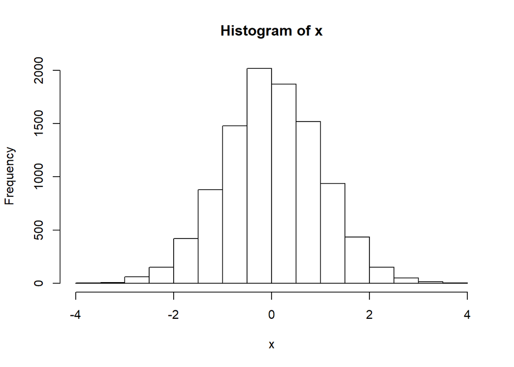

```r
x <- rnorm(10000)
hist(x)  # this is a histogram
```

```r
t.test(x)
```

```
##
##  One Sample t-test
##
## data:  x
## t = 0.76672, df = 9999, p-value = 0.4433
## alternative hypothesis: true mean is not equal to 0
## 95 percent confidence interval:
##  -0.01187605  0.02713499
## sample estimates:
##   mean of x
## 0.007629468
```

You can also insert “inline” results, like the following:

The mean of `x` is 0.0076295.

More documentation on Markdown and R Markdown: Help > Markdown Quick Reference Help > RStudio Docs

# Environments and `save()`/`load()`

- the basic R “workspace” is the Global Environment
  - aka `.GlobalEnv`
- “save workspace image?” question
  - recommend: no
  - not reproducible
  - helps perpetuate “bad programming hygiene”
  - ends up in .RData file (no name in front of .RData)
- *BEST PRACTICE*:
  - save code in script/notebook
  - save data in (non-proprietary) simple formats (CSV, etc.)
  - helps transparency, reproducibility, portability
- HOWEVER:
  - sometimes the result of an R function has non-trivial overhead (time)
  - *for convenience*, it can be handy to save R objects in a “native” format
  - `save()` then later `load()`

```r
x <- rnorm(100, mean = 0, sd = 2)
y <- rnorm(100, mean = 1, sd = 1)
ttest.results <- t.test(x, y)
# ttest.results

# what if ttest.results took minutes/hours to compute?
save(ttest.results, file = "big important object.RData")
# ttest.results
# rm(ttest.results)
# ttest.results
load("big important object.RData")
ttest.results
```

```
##
##  Welch Two Sample t-test
##
## data:  x and y
## t = -3.6297, df = 152.61, p-value = 0.0003866
## alternative hypothesis: true difference in means is not equal to 0
## 95 percent confidence interval:
##  -1.2004806 -0.3542462
## sample estimates:
## mean of x mean of y
##  0.243384  1.020747
```

```r
save.image() # saves the *entire* workspace in .RData
save.image(file = "workspace.RData") # allows you to specify a name for the file
                                     # not loaded by default
```

# Reading and writing data/files

## Basic concepts:

- not “opening” files, but rather:
  - “reading” means “pulling data from a file into the workspace”
  - “writing” means “writing data from the workspace into a file”
- approach:
  1. Read data from whatever sources you need (from local files, from internet, whatever)
  2. Work with data in R (workspace)
  3. Write out whatever files you want to
  - updated/cleaned data
  - table of results/coefficients
  - plots
  - whatever you want! (and can program)

## Weird file types

Package for reading Excel data: `readxl`

- makes it easier to deal with Excel (esp .xslx files) without needing to export to CSV

Package for other stats packages (SPSS, SAS, Stata): `haven`

“Tidyverse” package for reading various kinds of data: `readr`

## Look at the options!

```r
?read.table

mydata <- read.csv(filename, na.strings = c("NA", "N/A", "n/a", " ", "nuthin"))

?readLines
?scan
```

## Writing files

```r
?write.table # .csv, etc.
```

Gotcha: - rownames!

```r
write.table(mydata, file = "outputfile.txt",
            sep = "\t",   # this makes the output tab-delimited
            row.names = FALSE)  # good for exporting data

write.csv(mydata, file = "outputfile.csv", row.names = FALSE) # good for writing CSVs
```

# Data types

- numeric
- logical
- character
- factor
- NA
- NULL
- others (e.g, “Date”)

## Numeric

- numbers!
- sometimes integers can differ from non-integers
- `as.numeric()` forces it to be a number (not integers)
- `1L` is an integer
- have mean, medians

A few handy things with numbers:

```r
# floating point pitfalls
x <- 0.1 + 0.2
x
```

```
## [1] 0.3
```

```r
x == 0.3
```

```
## [1] FALSE
```

```r
# "e" notation for really big numbers
1e4
```

```
## [1] 10000
```

```r
# round(), floor(), ceiling()
x2 <- round(x, 1)
x2 == 0.3
```

```
## [1] TRUE
```

```r
# sample(), rnorm(), rbinom()
sample(10)
```

```
##  [1]  1 10  4  8  6  2  9  5  7  3
```

```r
# ?sample

sample(1:10, size = 4, replace = FALSE)
```

```
## [1] 8 1 6 9
```

```r
sample(1:10, size = 4, replace = FALSE)
```

```
## [1]  5  7 10  2
```

```r
# sample(1:10, size = 12, replace = FALSE)

sample(1:10, size = 12, replace = TRUE)
```

```
##  [1]  3  2  6  9  2  4  4 10 10  6  9  8
```

```r
rnorm(10)
```

```
##  [1] -0.09347484  0.48923395  0.19216918  0.27618328 -0.92019580
##  [6] -0.13691721 -0.03862052  1.00171501  0.51311563 -1.03532438
```

```r
rbinom(5, size = 10, prob = .2)
```

```
## [1] 3 5 2 4 1
```

```r
many.flips <- rbinom(1e6, size = 10, prob = .2)
mean(many.flips)
```

```
## [1] 2.000493
```

```r
# the r/p/d/q families


# quantile()
x <- rnorm(1e5, mean = 2, sd = 5)
quantile(x)
```

```
##         0%        25%        50%        75%       100%
## -20.070263  -1.367497   2.013707   5.365424  22.976713
```

```r
quantile(x, seq(0, 1, .1))
```

```
##          0%         10%         20%         30%         40%         50%
## -20.0702632  -4.4250011  -2.2193671  -0.6022033   0.7381035   2.0137068
##         60%         70%         80%         90%        100%
##   3.2798850   4.6284172   6.2141979   8.4192834  22.9767128
```

## Logicals

- TRUE and FALSE
- if coerced to `as.numeric`, TRUE == 1, FALSE == 0
  - can take the mean of a logical vector
- Shortcuts: T and F
  - *DANGER*: T and F can be overwritten
- logical operators create logical vectors
  - `==`
  - `>`
  - `<`
  - `|` This is the “long bar”, meaning (inclusive) “or” (aka “pipe”)
  - `&` == “and”
  - `>=` greater or equal
  - `!` is NOT
  - `&&` and `||` for more specific programming situations

```r
# operators vs. functions
2 + 2
```

```
## [1] 4
```

```r
`+`(2, 2)
```

```
## [1] 4
```

```r
# basic forms
1 > 2
```

```
## [1] FALSE
```

```r
1 < 2
```

```
## [1] TRUE
```

```r
class(1)
```

```
## [1] "numeric"
```

```r
class(TRUE)
```

```
## [1] "logical"
```

```r
class(1 < 2)
```

```
## [1] "logical"
```

```r
class("1")
```

```
## [1] "character"
```

```r
1 == 2
```

```
## [1] FALSE
```

```r
x <- "a string"
x == "a string"
```

```
## [1] TRUE
```

```r
x != "a string"
```

```
## [1] FALSE
```

```r
x != 2
```

```
## [1] TRUE
```

```r
x <- 1:5

x <= 3
```

```
## [1]  TRUE  TRUE  TRUE FALSE FALSE
```

```r
x >= 3
```

```
## [1] FALSE FALSE  TRUE  TRUE  TRUE
```

```r
TRUE & TRUE
```

```
## [1] TRUE
```

```r
TRUE & FALSE
```

```
## [1] FALSE
```

```r
TRUE | FALSE
```

```
## [1] TRUE
```

```r
x <- 1:6
x < 3
```

```
## [1]  TRUE  TRUE FALSE FALSE FALSE FALSE
```

```r
x > 4
```

```
## [1] FALSE FALSE FALSE FALSE  TRUE  TRUE
```

```r
(x > 2) & (x < 5) # parens not necessary here
```

```
## [1] FALSE FALSE  TRUE  TRUE FALSE FALSE
```

```r
! TRUE
```

```
## [1] FALSE
```

```r
x > 2
```

```
## [1] FALSE FALSE  TRUE  TRUE  TRUE  TRUE
```

```r
!x > 2
```

```
## [1]  TRUE  TRUE FALSE FALSE FALSE FALSE
```

```r
!(x > 2)
```

```
## [1]  TRUE  TRUE FALSE FALSE FALSE FALSE
```

```r
!(x > 4 | x < 3)
```

```
## [1] FALSE FALSE  TRUE  TRUE FALSE FALSE
```

```r
# "shortcut" forms (avoid!)
F
```

```
## [1] FALSE
```

```r
T
```

```
## [1] TRUE
```

```r
F <- TRUE
F # uh oh
```

```
## [1] TRUE
```

```r
# examples of comparisons

# which()
x < 5
```

```
## [1]  TRUE  TRUE  TRUE  TRUE FALSE FALSE
```

```r
set.seed(42)
x <- sample(1:10, 100, replace = TRUE)
x == 7
```

```
##   [1] FALSE FALSE FALSE FALSE  TRUE FALSE FALSE FALSE  TRUE FALSE FALSE
##  [12] FALSE FALSE FALSE FALSE FALSE FALSE FALSE FALSE FALSE FALSE FALSE
##  [23] FALSE FALSE FALSE FALSE FALSE FALSE FALSE FALSE FALSE FALSE FALSE
##  [34]  TRUE FALSE FALSE FALSE FALSE FALSE  TRUE FALSE FALSE FALSE FALSE
##  [45] FALSE FALSE FALSE  TRUE FALSE  TRUE FALSE FALSE FALSE FALSE FALSE
##  [56] FALSE  TRUE FALSE FALSE FALSE  TRUE FALSE FALSE FALSE FALSE FALSE
##  [67] FALSE FALSE  TRUE FALSE FALSE FALSE FALSE FALSE FALSE FALSE FALSE
##  [78] FALSE FALSE FALSE FALSE FALSE FALSE  TRUE FALSE FALSE FALSE FALSE
##  [89] FALSE FALSE  TRUE FALSE FALSE FALSE FALSE FALSE FALSE FALSE FALSE
## [100]  TRUE
```

```r
which(x == 7)
```

```
##  [1]   5   9  34  40  48  50  57  61  69  84  91 100
```

```r
# logicals for subsetting

# %in%
all.values <- c("a", "b", "c", "d")
x <- sample(all.values, 100, TRUE)

try1 <- x == c("a", "b") # NOPE
try2 <- x %in% c("a", "b") # this is usually what you want

x1 <- c(1, 2, 7, 32)
x2 <- c(1, 5, 8, 32)

x1 == x2
```

```
## [1]  TRUE FALSE FALSE  TRUE
```

```r
x1 == c(1, 2)
```

```
## [1]  TRUE  TRUE FALSE FALSE
```

```r
# identical()
```

PRACTICE! #0 – #2 in the “day03_practice.Rmd” file

Try “knitting” the result!

- need to set “Knit directory” to the project directory!
- can be down with the Knit dropdown